# Hw4_math564

V. V. Dhanvanthar M. [A20543395]

2024-09-27

## Question 1

```r
library("tidyverse")
#View(mtcars)
?mtcars
```

```
## starting httpd help server ... done
```

```r
my_data <-mtcars %>%
  select(mpg, cyl, disp, hp, wt)
model1<- lm(mpg~cyl+disp+hp+wt, data = my_data)
summary(model1)
```

```
##
## Call:
## lm(formula = mpg ~ cyl + disp + hp + wt, data = my_data)
##
## Residuals:
##     Min      1Q  Median      3Q     Max
## -4.0562 -1.4636 -0.4281  1.2854  5.8269
##
## Coefficients:
##             Estimate Std. Error t value Pr(>|t|)
## (Intercept) 40.82854    2.75747  14.807 1.76e-14 ***
## cyl         -1.29332    0.65588  -1.972 0.058947 .
## disp         0.01160    0.01173   0.989 0.331386
## hp          -0.02054    0.01215  -1.691 0.102379
## wt          -3.85390    1.01547  -3.795 0.000759 ***
## ---
## Signif. codes:  0 '***' 0.001 '**' 0.01 '*' 0.05 '.' 0.1 ' ' 1
##
## Residual standard error: 2.513 on 27 degrees of freedom
## Multiple R-squared:  0.8486, Adjusted R-squared:  0.8262
## F-statistic: 37.84 on 4 and 27 DF,  p-value: 1.061e-10
```

## 1a)

```r
my_data2 <-mtcars %>%
  select(mpg, cyl, hp, wt)
model2<- lm(mpg~cyl+hp+wt, data = my_data2)
summary(model2)
```

```
##
## Call:
## lm(formula = mpg ~ cyl + hp + wt, data = my_data2)
##
## Residuals:
##     Min      1Q  Median      3Q     Max
## -3.9290 -1.5598 -0.5311  1.1850  5.8986
##
## Coefficients:
##             Estimate Std. Error t value Pr(>|t|)
## (Intercept) 38.75179    1.78686  21.687  < 2e-16 ***
## cyl         -0.94162    0.55092  -1.709 0.098480 .
## hp          -0.01804    0.01188  -1.519 0.140015
## wt          -3.16697    0.74058  -4.276 0.000199 ***
## ---
## Signif. codes:  0 '***' 0.001 '**' 0.01 '*' 0.05 '.' 0.1 ' ' 1
##
## Residual standard error: 2.512 on 28 degrees of freedom
## Multiple R-squared:  0.8431, Adjusted R-squared:  0.8263
## F-statistic: 50.17 on 3 and 28 DF,  p-value: 2.184e-11
```

## 1b)

Looking into p-values in model2 case, we observe wt has the least p-value(0.000199) explaining its significance among the features selected and hp having the highest(0.140015). So we drop this for next model fitting.

```r
my_data3 <-mtcars %>%
  select(mpg, cyl, wt)
model3<- lm(mpg~cyl+wt, data = my_data3)
summary(model3)
```

```
##
## Call:
## lm(formula = mpg ~ cyl + wt, data = my_data3)
##
## Residuals:
##     Min      1Q  Median      3Q     Max
## -4.2893 -1.5512 -0.4684  1.5743  6.1004
##
## Coefficients:
##             Estimate Std. Error t value Pr(>|t|)
## (Intercept)  39.6863     1.7150  23.141  < 2e-16 ***
## cyl          -1.5078     0.4147  -3.636 0.001064 **
## wt           -3.1910     0.7569  -4.216 0.000222 ***
## ---
## Signif. codes:  0 '***' 0.001 '**' 0.01 '*' 0.05 '.' 0.1 ' ' 1
##
## Residual standard error: 2.568 on 29 degrees of freedom
## Multiple R-squared:  0.8302, Adjusted R-squared:  0.8185
## F-statistic: 70.91 on 2 and 29 DF,  p-value: 6.809e-12
```

## 1c)

In this model considering the cutoff for p-value as 0.05, we obtain both the features are significant since both have p-values less than 0.05.

## 1d)

We know that R-squared gives us understanding on how well the model is fitting the data and explains the variability in dependent variable. In this case, even with 2 features, the R-squared is 0.8302 which explains that both the selected features are highly correlated with fuel efficiency(mpg), We can infer that, Heavier cars and cars with more cylinders tend to have lower fuel efficiency, so these two predictors can explain a substantial portion of the variability in mpg.

## Question 2

## 2a)

```r
library("ISLR2")
?Carseats
my_data <-Carseats %>%
  select(Sales, Advertising, Price)
model1<- lm(Sales~Advertising+Price, data = my_data)
summary(model1)
```

```
##
## Call:
## lm(formula = Sales ~ Advertising + Price, data = my_data)
##
## Residuals:
##     Min      1Q  Median      3Q     Max
## -7.9011 -1.5470 -0.0223  1.5361  6.3748
##
## Coefficients:
##              Estimate Std. Error t value Pr(>|t|)
## (Intercept) 13.003427   0.606850  21.428  < 2e-16 ***
## Advertising  0.123107   0.018079   6.809 3.64e-11 ***
## Price       -0.054613   0.005078 -10.755  < 2e-16 ***
## ---
## Signif. codes:  0 '***' 0.001 '**' 0.01 '*' 0.05 '.' 0.1 ' ' 1
##
## Residual standard error: 2.399 on 397 degrees of freedom
## Multiple R-squared:  0.2819, Adjusted R-squared:  0.2782
## F-statistic: 77.91 on 2 and 397 DF,  p-value: < 2.2e-16
```

## 2b)

We can reject null hypothesis on both the features after looking at their p-values. That is, with cutoff of p-value as 0.05, we observe both selected features are proven to be significant implying that they have a relation with the target feature.

## 2c)

Even though the p-values are proving the two features are significant, the R-squared metric gives a different view to the problem. The R-squared value is 0.28, which explains these 2 features are only capable of explaining 28% of variability in sales(target variable). Which means around 71.8% of variability in sales is not explained by advertising and price.

## Question 3

```r
#load the txt file and named it as data1
data1 <- read.table("MMass.txt", header = FALSE)

#showing the first 6 data points
head(data1)
```

```
##    V1 V2
## 1 106 43
## 2 106 41
## 3  97 47
## 4 113 46
## 5  96 45
## 6 119 41
```

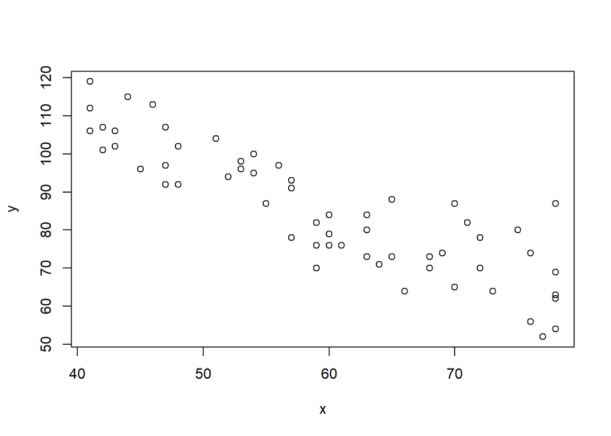

```r
#Rename variables
x <- data1$V2
y <- data1$V1

#plotting data
plot(x,y)
```

## 3a)

```r
#fitting linear regression
model <- lm(y~x)
summary(model)
```

```
##
## Call:
## lm(formula = y ~ x)
##
## Residuals:
##      Min       1Q   Median       3Q      Max
## -16.1368  -6.1968  -0.5969   6.7607  23.4731
##
## Coefficients:
##             Estimate Std. Error t value Pr(>|t|)
## (Intercept) 156.3466     5.5123   28.36   <2e-16 ***
## x            -1.1900     0.0902  -13.19   <2e-16 ***
## ---
## Signif. codes:  0 '***' 0.001 '**' 0.01 '*' 0.05 '.' 0.1 ' ' 1
##
## Residual standard error: 8.173 on 58 degrees of freedom
## Multiple R-squared:  0.7501, Adjusted R-squared:  0.7458
## F-statistic: 174.1 on 1 and 58 DF,  p-value: < 2.2e-16
```

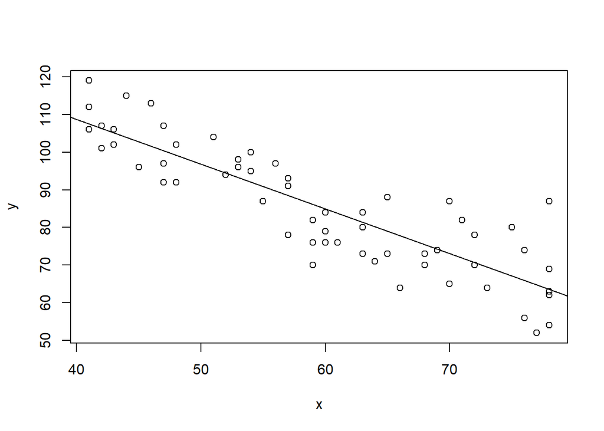

```r
plot(x, y)
abline(model)
```

## 3b)

The point estimate of the average change in muscle mass for women differing in age by one year is represented by the slope coefficient of the regression model In the summary of model, we can see the x coefficient(estimated slope) is -1.1900. The negative sign indicates the x and y negatively correlated. This means that for every additional year of age, the muscle mass decreases by approximately 1.19 units on average. Thus, the point estimate of the average change in muscle mass for women differing in age by one year is -1.19 units

## 3c)

We know point estimate of sigma square (constant variance of E) is the sample variance of constant variance. We have RSE = 8.173 = sqrt(RSS/n-p) n-p = degree of freedom = 58.

RSS = (8.173) ^ 2 x (n-p) RSS = 66.79 x (n-p) … (1)

we know point estimate of sigma square = RSS/(n-p) … (2)

substitute equation 1 in 2.

Point estimate of constant variance = 66.79.

## 3d)

R-squared = 0.7501 This implies approximately 75% of variance in muscle mass is explained by age. The higher r-squared value, the better the model fit is. P-value = 2.2e-16 <<< 0.05 This indicates the age is a significant feature in predicting the muscle mass. Both these metrics suggests that linear regression model seem to provide a good fit for the data.

The plot and the cofficient of x(negative) both indicate that muscle mass decreases with increase in age.